# Practical Machine Learning

herchu

### Summary

It’s possible to predict with very high accuracy the quality of weight lifting exercises from data obtained from devices weared by the weightlifter. Using the data-set provided by [Velloso, E. et al.(2013)](http://groupware.les.inf.puc-rio.br/work.jsf?p1=11201) and a Random Forest model [Breiman, L.(2001)](https://www.stat.berkeley.edu/~breiman/randomforest2001.pdf) I could predict with 99.2% accuracy the quality of the workout.

### Preprocessing

In this analysis, an assignment for Coursera’s Practical Machine Learning course, two sets of data were used. Both sets comes from Velloso et al., and one of them is a 20 records sample that is used for assignment grading.

The data-set consists of weareable instrument measures collected from participants of an experiment where the subjects perform a workout and the quality of the exercise. The quality was recorded as 5 letters being “A” when the workout was perfomed correctly and “B” to “E” common mistakes. The data-set contains other variables like an index, the subject name, date and time of the observation.

By studying the provided files I found that the sets contains a large quantity of records with missing values. These comes either as a `"NA"` string or as blank string. There are other values that are identified as `#DIV/0!` (division by zero error) as well. I processed all of those as NA values.

```r
pmldata <- read.csv("pml-training.csv", stringsAsFactors=T, na.strings=c("NA","","#DIV/0!"))
pmlanswers <- read.csv("pml-testing.csv", stringsAsFactors=T, na.strings=c("NA","","#DIV/0!"))
```

The features that contains NAs provide very few measurements. The feature that contains the least NA values has 98% of all the values as NA. That’s a very high percentage (other feature are even worst) and it’s not worth to devise an imputation method for them. My decision was to get rid of those features in the model.

Alongside with the NAs goes some other features. I preferred to build a model that only contains instrument measurements so the prediction model can work in other situations (different users, time of day, etc.) feeded by the same instruments that were used in the aforementioned experiment. The result is a data set of 19,622 observations of 53 variables. All the predictors are numeric except the predicted value `classe` which is a factor.

```r
pmldatanona <- pmldata[,colSums(is.na(pmldata)) == 0]
ignorecols <- c('X','user_name','raw_timestamp_part_1','raw_timestamp_part_2',
                'cvtd_timestamp','new_window','num_window')
pmldatanona <- pmldatanona[,!(names(pmldatanona) %in% ignorecols)]
```

### Creating data sets

I created two data-sets (training and testing) both from the `pml-training.csv` file. The idea is to consider the `pml-testing.csv` file as the validating set whose results will be obtained through the course web page. My training and testing data-set consist of an 80/20% each sampling from the `pml-training.csv` file (*hold-out cross validation technique*).

```r
set.seed(101)
inTrain = createDataPartition(pmldatanona$classe, p = .8)[[1]]
training = pmldatanona[inTrain,]
testing = pmldatanona[-inTrain,]
```

### Model Selection

I’ve chosen the Random Forest classification method [Breiman, L. (2001)](https://www.stat.berkeley.edu/~breiman/randomforest2001.pdf) because its accuracy is well regarded. The resulting model from this algorithm is hard to interpret but, in this problem, given the number of features that are involved any interpretation will be difficult to prove.

Training of the random forest was done using one model. While the `caret` package let train several models with different parameters and evaluates them before choosing the best of the set, the process time tends to be very large and it’s better to start with a simple model and refine them later if needed. The parameter `mtry` is the number of variables available for splitting at each tree node while training. In [Cutler et al. (2007)](https://www.nescent.org/wg/cart/images/1/1a/HighResRandomForestsandAppendices.pdf) is reported that mtry doesn’t seem to affect the correct classification rates so I picked the smallest to speed up the calculations.

```r
set.seed(107)
modfit <- train(classe ~. , data=training, method="rf",
                tuneGrid=data.frame(mtry=1),
                trControl=trainControl(method="none"))
```

```r
modfit$finalModel
```

```
##
## Call:
##  randomForest(x = x, y = y, mtry = param$mtry)
##                Type of random forest: classification
##                      Number of trees: 500
## No. of variables tried at each split: 1
##
##         OOB estimate of  error rate: 0.8%
## Confusion matrix:
##      A    B    C    D    E class.error
## A 4461    1    0    1    1 0.000672043
## B   18 3009   11    0    0 0.009545754
## C    0   23 2713    2    0 0.009130752
## D    0    0   59 2513    1 0.023319083
## E    0    0    3    6 2877 0.003118503
```

As shown the out-of-bag error reported for this model is very small. At this point with the oob error reported it’s not worth to tweak the model and risk overfitting.

The following figure shows the variable importance in the resulting model (the 20 most important ordered by decreasing importance). One possible improvement could be run subsequent forests with only these variables.

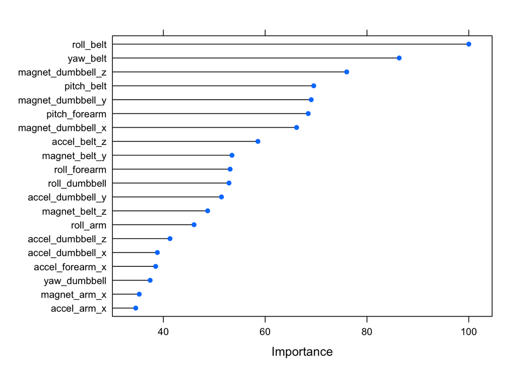

### Testing

One neat advantage of the Random Forest algorithm is that an extra cross-validation process to report the out of sample error is not needed as the model does it by itself during the building process. In the random forest jargon it’s called oob (out-of-bag) error. Its author, see [Breiman](https://www.stat.berkeley.edu/~breiman/RandomForests/cc_home.htm#ooberr), details how it’s obtained and why with RF the **extra cross-validation step is not needed**.

Regardless of this, I used the 20% of the original data-set (the hold-out cross-validation set) and built a confusion matrix against the predicted values from my model. The accuracy of the model with this sampled data is `0.9921` which corresponds nicely to the `0.8%` reported by the model (`accuracy = 1 - classif_error`).

```r
confusionMatrix(predict(modfit, newdata=testing), testing$classe)
```

```
## Confusion Matrix and Statistics
##
##           Reference
## Prediction    A    B    C    D    E
##          A 1115    4    0    0    0
##          B    0  754   10    0    0
##          C    0    1  674   14    0
##          D    0    0    0  629    1
##          E    1    0    0    0  720
##
## Overall Statistics
##
##                Accuracy : 0.9921
##                  95% CI : (0.9888, 0.9946)
##     No Information Rate : 0.2845
##     P-Value [Acc > NIR] : < 2.2e-16
##
##                   Kappa : 0.99
##  Mcnemar's Test P-Value : NA
##
## Statistics by Class:
##
##                      Class: A Class: B Class: C Class: D Class: E
## Sensitivity            0.9991   0.9934   0.9854   0.9782   0.9986
## Specificity            0.9986   0.9968   0.9954   0.9997   0.9997
## Pos Pred Value         0.9964   0.9869   0.9782   0.9984   0.9986
## Neg Pred Value         0.9996   0.9984   0.9969   0.9957   0.9997
## Prevalence             0.2845   0.1935   0.1744   0.1639   0.1838
## Detection Rate         0.2842   0.1922   0.1718   0.1603   0.1835
## Detection Prevalence   0.2852   0.1947   0.1756   0.1606   0.1838
## Balanced Accuracy      0.9988   0.9951   0.9904   0.9890   0.9992
```

### Assignment Results

To obtain the answers for the assignment I’ve just predict them using my model.

```r
answers <- predict(modfit, newdata=pmlanswers)
```

The results are ommited in this document for obvious reasons but I can confirm that with my model I’ve got 100% accuracy.

### Conclusions

In this analysis I found that it’s possible to predict with a very high accuracy (more than 99%) the quality of the workout sportsmen and sportswomen perform by taking measurements of accelerometers placed in their bodies.

While the Random Forest algorithm takes a long time to build the model, once it’s done the prediction phase is extremely fast. The model could be built beforehand and embedded into a device with several sensors for collecting the data. This device only need to capture the measurements and predict a result.

It’s not far fetched to imagine that in the near future we’ll see an automated personal trainer reporting how the exercises are performed in real-time through visual or auditive feedback.